# sfig15cd-tfiiic-bbox: TFIIIC B-box

Melanie (1028-02098-001-001)

October 02, 2020

# Introduction

Given the TFIIIC B-box, we seek to observe the Oct4 binding dynamics surrounding this motif returned by TF-MoDISco.

The B-box bound by the TFIIIC POLIII subunit. Typically, the B-box will be located across genes and not be upstream or downstream. We will look at regions that contain tRNA genes and the 5S rRNA gene to see what kind of overlap there is.

# Computational Setup

```r
#Standard packages
library(rtracklayer) ; library(GenomicRanges); library(magrittr) ; library(Biostrings)
library(ggplot2) ; library(reshape2); library(plyranges); library(Rsamtools); library(data.table)
library(BSgenome.Mmusculus.UCSC.mm10); library(plyr); library(viridis); library(dplyr)

#KNITR Options
setwd("/n/projects/mw2098/publications/2019_bpnet/")
options(knitr.figure_dir="figures/23-sfig15cd-tfiiic-bbox_manuscript_data", width=16, height=20)

#Lab sources
source("rscripts/granges_common.r")
source("rscripts/knitr_common.r")
source("rscripts/caching.r")
source("rscripts/multiplot.R")
source("rscripts/metapeak_functions.R")
source("rscripts/metapeak_common.r")

#Specific packages
library(stringr)
library(GenomicScores) #phastCONS
library(ggrepel)
library(TxDb.Mmusculus.UCSC.mm10.ensGene)
library(mygene)
library(ggforce)
library(grid)
library(gtable)
library(gridExtra)

#Custom fxn
simpleCap <- function(x) {
  s <- strsplit(x, " ")[[1]]
  paste(toupper(substring(s, 1,1)), substring(s, 2),
      sep="", collapse=" ")
}
```

# Define data paths

```r
#BED file with coordinates of each seqlet location returned by TF-MoDISco.
seqlet_coordinates_filepath <- "data/bed/seqlet_coordinates.bed"

#BED file with coordinates of each predicted tRNA site obtained from http://gtrnadb.ucsc.edu/, see the tRNA section below for details
trna_coordinates_filepath <- "data/bed/mm10-tRNAs.bed" #

#ChIP-nexus samples were combined across replicates, blacklisted according to mm10, and normalized to reads per million (RPM).
sample.list=list(oct4=list(pos="data/bw/nexus/mesc_oct4_nexus_combined_filtered_normalized_positive.bw",
                           neg="data/bw/nexus/mesc_oct4_nexus_combined_filtered_normalized_negative.bw"))
```

# Prepare Bbox seqlet data

## Get PhastCon scores across each seqlet

```r
gscores_mm10 <- getGScores("phastCons60way.UCSC.mm10")

#Select all regions containing this motif
bbox<-import(seqlet_coordinates_filepath) %>% subset(., name=="Klf4_11" | name=="Oct4_5" | name=="Sox2_3")
bbox_with_cons<-gscores(x = gscores_mm10, ranges = bbox)

seqlevels(bbox_with_cons)<-seqlevels(TxDb.Mmusculus.UCSC.mm10.ensGene)
seqinfo(bbox_with_cons)<-seqinfo(TxDb.Mmusculus.UCSC.mm10.ensGene)
saveRDS(bbox_with_cons, "data/rdata/bbox/b_box_regions_with_phastcons_scores.granges.rds")
```

## Trim and align different bbox seqlets

We will need palindromic regions that allow for B-box consolidation across motifs with different flanks.

```r
gscores_mm10 <- getGScores("phastCons60way.UCSC.mm10")
bbox_regions<-readRDS("data/rdata/bbox/rdata/b_box_regions_with_phastcons_scores.granges.rds")

bbox_regions_trimmed<-lapply(unique(bbox_regions$name), function(x){
  gr_orig<-subset(bbox_regions, name==x) #create original granges as reference for start/end sites
  gr<-subset(bbox_regions, name==x)
  if(x=="Oct4_5"){
    offset<-4
    start(gr[which(strand(gr)=="+")])<-start(gr_orig[which(strand(gr)=="+")]) + offset #if strand(gr) is +
    end(gr[which(strand(gr)=="+")])<-start(gr_orig[which(strand(gr)=="+")]) + offset + 11
    start(gr[which(strand(gr)=="-")])<-end(gr_orig[which(strand(gr)=="-")]) - offset - 11 #if strand(gr) is -
    end(gr[which(strand(gr)=="-")])<-end(gr_orig[which(strand(gr)=="-")]) - offset
  }

  if(x=="Sox2_3"){
    offset<-18
    start(gr[which(strand(gr)=="+")])<-start(gr_orig[which(strand(gr)=="+")]) + offset #if strand(gr) is +
    end(gr[which(strand(gr)=="+")])<-start(gr_orig[which(strand(gr)=="+")]) + offset + 11
    start(gr[which(strand(gr)=="-")])<-end(gr_orig[which(strand(gr)=="-")]) - offset - 11 #if strand(gr) is -
    end(gr[which(strand(gr)=="-")])<-end(gr_orig[which(strand(gr)=="-")]) - offset
  }

  if(x=="Klf4_11"){
    offset<-12
    start(gr[which(strand(gr)=="+")])<-start(gr_orig[which(strand(gr)=="+")]) + offset #if strand(gr) is +
    end(gr[which(strand(gr)=="+")])<-start(gr_orig[which(strand(gr)=="+")]) + offset + 11
    start(gr[which(strand(gr)=="-")])<-end(gr_orig[which(strand(gr)=="-")]) - offset - 11 #if strand(gr) is -
    end(gr[which(strand(gr)=="-")])<-end(gr_orig[which(strand(gr)=="-")]) - offset
  }

  return(gr)
}) %>% as(Class="GRangesList") %>% unlist
bbox_regions_trimmed_comb<-bbox_regions_trimmed %>% resize(width=1, "start") %>% reduce %>% resize(width=12, "start")
bbox_regions_trimmed_comb_with_cons<-gscores(x = gscores_mm10, ranges = bbox_regions_trimmed_comb)

seqlevels(bbox_regions_trimmed_comb_with_cons)<-seqlevels(TxDb.Mmusculus.UCSC.mm10.ensGene)
seqinfo(bbox_regions_trimmed_comb_with_cons)<-seqinfo(TxDb.Mmusculus.UCSC.mm10.ensGene)
saveRDS(bbox_regions_trimmed_comb_with_cons, "data/rdata/bbox/b_box_regions_trimmed_combined_with_phastcons_scores.granges.rds")
```

Read in B-box regions. Read in both (1) the raw seqlet locations and (2) the regions that are trimmed to the palindromic portion of the B-box [GGGTTCGAACCC].

```r
bbox_regions<-readRDS("data/rdata/bbox/b_box_regions_with_phastcons_scores.granges.rds")
bbox_regions_trimmed_comb_with_cons<-readRDS("data/rdata/bbox/b_box_regions_trimmed_combined_with_phastcons_scores.granges.rds")
mm10_genes<-genes(TxDb.Mmusculus.UCSC.mm10.ensGene)
```

# Overlap bbox with different RNA types

## 5S rRNAs

Do any B-box seqlets occur over the 5S rRNA gene?

```r
rrna_5s<-mm10_genes["ENSMUSG00000096406"]
findOverlaps(resize(rrna_5s, 100000, "center"), bbox_regions, ignore.strand=T)
```

```
## Hits object with 0 hits and 0 metadata columns:
##    queryHits subjectHits
##    <integer>   <integer>
##   -------
##   queryLength: 1 / subjectLength: 1297
```

## tRNAs

For the identification of tRNAs we will be using tRNAscan-SE. According to documentation found on UCSC:

"tRNAscan-SE is an integrated program that uses tRNAscan (Fichant) and an A/B box motif detection algorithm (Pavesi) as pre-filters to obtain an initial list of tRNA candidates. The program then filters these candidates with a covariance model-based search program COVE (Eddy) to obtain a highly specific set of primary sequence and secondary structure predictions that represent 99-100% of true tRNAs with a false positive rate of fewer than 1 per 15 gigabases.

What does the tRNAscan-SE score mean? Anything with a score above 20 bits is likely to be derived from a tRNA, although this does not indicate whether the tRNA gene still encodes a functional tRNA molecule (i.e. tRNA-derived SINES probably do not function in the ribosome in translation). Vertebrate tRNAs with scores of >60.0 (bits) are likely to encode functional tRNA genes, and those with scores below ~45 have sequence or structural features that indicate they probably are no longer involved in translation. tRNAs with scores between 45-60 bits are in the “grey” zone, and may or may not have all the required features to be functional. In these cases, tRNAs should be inspected carefully for loss of specific primary or secondary structure features (usually in alignments with other genes of the same isotype), in order to make a better educated guess. These rough score range guides are not exact, nor are they based on specific biochemical studies of atypical tRNA features, so please treat them accordingly.

Please note that tRNA genes marked as “Pseudo” are low scoring predictions that are mostly pseudogenes or tRNA-derived elements. These genes do not usually fold into a typical cloverleaf tRNA secondary structure and the provided images of the predicted secondary structures may appear rotated."

Kudos: http://rohsdb.cmb.usc.edu/GBshape/cgi-bin/hgTables?db=mm10&hgta_group=genes&hgta_track=tRNAs&hgta_table=tRNAs&hgta_doSchema=describe+table+schema Kudos: http://gtrnadb.ucsc.edu/

```r
#Overlap between tRNAs
trnas<-import(trna_coordinates_filepath)
trna_and_bbox_overlap<-findOverlaps(trnas, bbox_regions_trimmed_comb_with_cons, ignore.strand=T)
overlap_percent<-round(length(unique(trna_and_bbox_overlap@to))/length(bbox_regions_trimmed_comb_with_cons)*100, 1) #29.7% overlap with predicted tRNAs
overlap_percent_df<-data.frame(overlap_pos=c("none", "tRNA gene overlap"), text=c(100-overlap_percent, overlap_percent))
overlap_percent_df
```

```
##         overlap_pos text
## 1              none 70.3
## 2 tRNA gene overlap 29.7
```

# Conservation of tRNA-overlapping and no-overlapping bbox

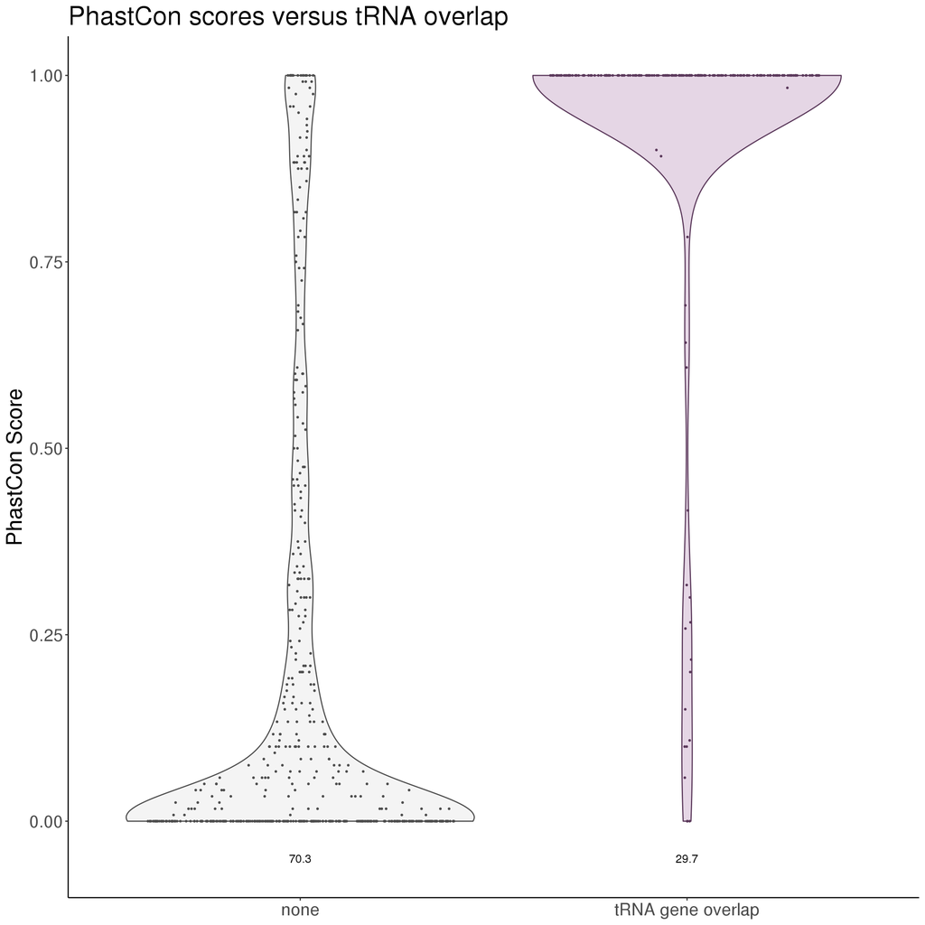

```r
#Does conservation correlate with overlap? We will now redo this analysis using the same width in conservation (the palindromic portion).
bbox_regions_trimmed_comb_with_cons$overlap<-"none"
bbox_regions_trimmed_comb_with_cons$overlap[unique(trna_and_bbox_overlap@to)]<-"tRNA gene overlap"
bbox_regions_overlap_check<-as.data.frame(bbox_regions_trimmed_comb_with_cons)
bbox_plot<-ggplot(bbox_regions_overlap_check, aes(overlap, default))+
  geom_violin(aes(fill=overlap, color=overlap), scale="area", alpha=.4)+
  geom_sina(aes(color=overlap), scale = T, size=.5, maxwidth=.8)+
  geom_text(data=overlap_percent_df, mapping=aes(x=overlap_pos, y=-.05, label=text))+
  scale_fill_manual(values=c("gray90", "#bf99bf"))+
  scale_color_manual(values=c("gray30", "#5b395b"))+
  ggtitle("PhastCon scores versus tRNA overlap")+
  ylab("PhastCon Score")+
  theme_classic()+
  theme(text=element_text(size=20), axis.title.x=element_blank(), legend.position="none")
print(bbox_plot)
```

```r
#ggsave("figures/bbox_phastcon_trna_overlaps.pdf", bbox_plot, height=4, width=2.4)
```

# tRNA-overlapping bbox versus tRNA class

## Amino acid and anticodon summary

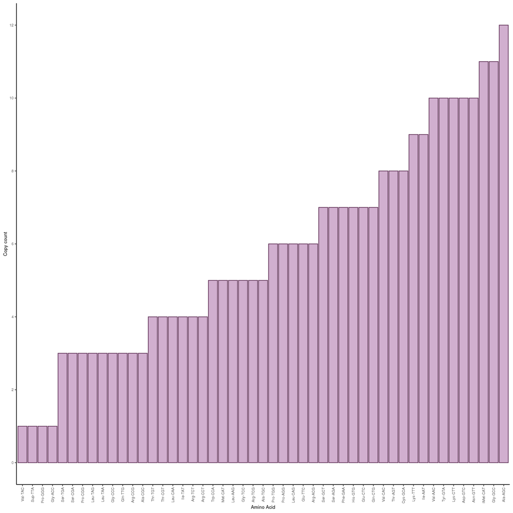

```r
#Prepare df
trnas_overlapping_with_bbox<-trnas[trna_and_bbox_overlap@from]
trnas_overlapping_with_bbox_df<-as.data.frame(trnas_overlapping_with_bbox)

#Split the name of the tRNA by a hyphen
trna_attributes<-lapply(trnas_overlapping_with_bbox_df$name, function(x){
  strsplit(x, "-") %>% unlist %>% as.data.frame() %>% transpose
}) %>% rbindlist()
colnames(trna_attributes)<-c("RNA_type", "aa", "anticodon", "genetic_level1", "genetic_level2")
trnas_overlapping_with_bbox_df <- cbind(trnas_overlapping_with_bbox_df, trna_attributes)
trnas_overlapping_with_bbox_df$short_name<-paste(trnas_overlapping_with_bbox_df$aa, trnas_overlapping_with_bbox_df$anticodon, sep="-") #integrate amino acids

#Summarize
aa_summary<-table(trnas_overlapping_with_bbox_df$short_name) %>% as.data.frame
aa_summary$Var1<-factor(aa_summary$Var1, levels=rev(aa_summary$Var1[order(aa_summary$Freq, decreasing=T)]))
aa_summary$freq_ratio<-aa_summary$Freq/sum(aa_summary$Freq)
aa_summary$type<-"actual_distribution"
aa_summary<-subset(aa_summary, Var1 != "Und" & Var1 != "SeC" & Var1 != "Sup") #Drop unknown levels

trna_frequency_plot<-ggplot(aa_summary, aes(Var1, Freq))+
  geom_bar(stat="identity", fill="#d1afcf", color="#5c2d53")+
  scale_y_continuous(breaks=seq(0, 13, 2), name="Copy count")+
  scale_x_discrete(name="Amino Acid")+
  #coord_flip()+
  theme_classic()+
  theme(text=element_text(size=8), axis.text.x=element_text(angle=90, hjust=1, vjust=.5), legend.position="none")
print(trna_frequency_plot)
```

# Amino acid summary

```r
aa_summary<-table(trnas_overlapping_with_bbox_df$aa) %>% as.data.frame
aa_summary$Var1<-factor(aa_summary$Var1, levels=aa_summary$Var1[order(aa_summary$Freq, decreasing=F)])
aa_summary<-subset(aa_summary, Var1 != "Und" & Var1 != "SeC" & Var1 != "Sup") #Drop unknown levels
#
# ggplot(aa_summary, aes(Var1, Freq))+
#   geom_bar(stat="identity")+
#   scale_y_continuous(name="Frequency")+
#   scale_x_discrete(name="Anticodon")+
#   coord_flip()+
#   ggtitle("tRNA overlapping B-box amino acid frequency")+
#   theme_classic()+
#   theme(text=element_text(size=20), legend.position="none")
```

# Testing presence of Oct1 (Oct4_like) upstream

Some models claim that Oct1 can bind upstream of TFIIIC to a binding site. Then, the DNA will loop and the Oct1 will be recruited to the tRNA start site. In order to validate this model, we want to check to see if we can find any Oct4-specific binding sites upstream of the tRNA up to 1kb.

```r
trnas_overlapping_with_bbox_upstream<-trnas_overlapping_with_bbox %>% resize(width=1, fix="start") %>% resize(width=1000, fix="end")

#Oct4-only
  matches_f<-vmatchPattern(pattern = "ATGC", subject = getSeq(BSgenome.Mmusculus.UCSC.mm10, trnas_overlapping_with_bbox_upstream), max.mismatch = 0, min.mismatch = 0) %>% as.list
  matches_r<-vmatchPattern(pattern = reverseComplement(DNAString("GCAT")), subject = getSeq(BSgenome.Mmusculus.UCSC.mm10, trnas_overlapping_with_bbox_upstream), max.mismatch = 0, min.mismatch = 0) %>% as.list
  names(matches_f)<-1:length(matches_f)
  names(matches_r)<-1:length(matches_r)
  matches_df<-rbind(lapply(matches_f, function(x) as.data.frame(x)) %>% rbindlist(idcol = "row"), lapply(matches_r, function(x) as.data.frame(x)) %>% rbindlist(idcol = "row"))

  #Number of regions that contain at least 1 match
  length(unique(matches_df$row))/length(trnas_overlapping_with_bbox_upstream)
```

```
## [1] 0.9116608
```

```r
  # #distribution of start sites
  # ggplot(matches_df, aes(-start))+
  #   geom_histogram(binwidth=1)

#Oct-Oct
  OO_matches_f<-vmatchPattern(pattern = reverseComplement(DNAString("TGCATATGCAT")), subject = getSeq(BSgenome.Mmusculus.UCSC.mm10, trnas_overlapping_with_bbox_upstream), max.mismatch = 2, min.mismatch = 0) %>% as.list
  OO_matches_r<-vmatchPattern(pattern = reverseComplement(DNAString("ATGCATATGCA")), subject = getSeq(BSgenome.Mmusculus.UCSC.mm10, trnas_overlapping_with_bbox_upstream), max.mismatch = 2, min.mismatch = 0) %>% as.list
  names(OO_matches_f)<-1:length(OO_matches_f)
  names(OO_matches_r)<-1:length(OO_matches_r)
  OO_matches_df<-rbind(lapply(OO_matches_f, function(x) as.data.frame(x)) %>% rbindlist(idcol = "row"), lapply(OO_matches_r, function(x) as.data.frame(x)) %>% rbindlist(idcol = "row"))

  #Number of regions that contain at least 1 match
  length(unique(OO_matches_df$row))/length(trnas_overlapping_with_bbox_upstream)
```

```
## [1] 0.1625442
```

```r
  #
  # #distribution of start sites
  # ggplot(OO_matches_df, aes(-start))+
  #   geom_histogram(binwidth=1)
```

91% of the regions contain at least 1 Oct4 site and 16% of them contain an Oct-Oct motif (with up to 2 mm). This match was investigated on both strands. However, the matches did not occur in any specific location.

# Reorient the Bbox motif relative to the tRNA

If we flip the motifs to the orientation of the tRNAs, this will help clarify the strands.

```r
#Reassign the strand to match tRNA orientation
bbox_overlap_str_reass<-bbox_regions_trimmed_comb_with_cons[unique(trna_and_bbox_overlap@to)]
strand(bbox_overlap_str_reass)<-strand(trnas[trna_and_bbox_overlap@from]) #reassign the strand

#Correct GRanges sequence alignment based on specific motif parameters
strand_is_pos<-which(strand(bbox_overlap_str_reass)=="+")
start(bbox_overlap_str_reass[strand_is_pos])<-start(bbox_overlap_str_reass[strand_is_pos]) + 1
```

## Plot Oct4 with strand reorientation

If we flip Oct4 to the orientation of the tRNAs that the B-box occurs across, can we consolidate the profile?

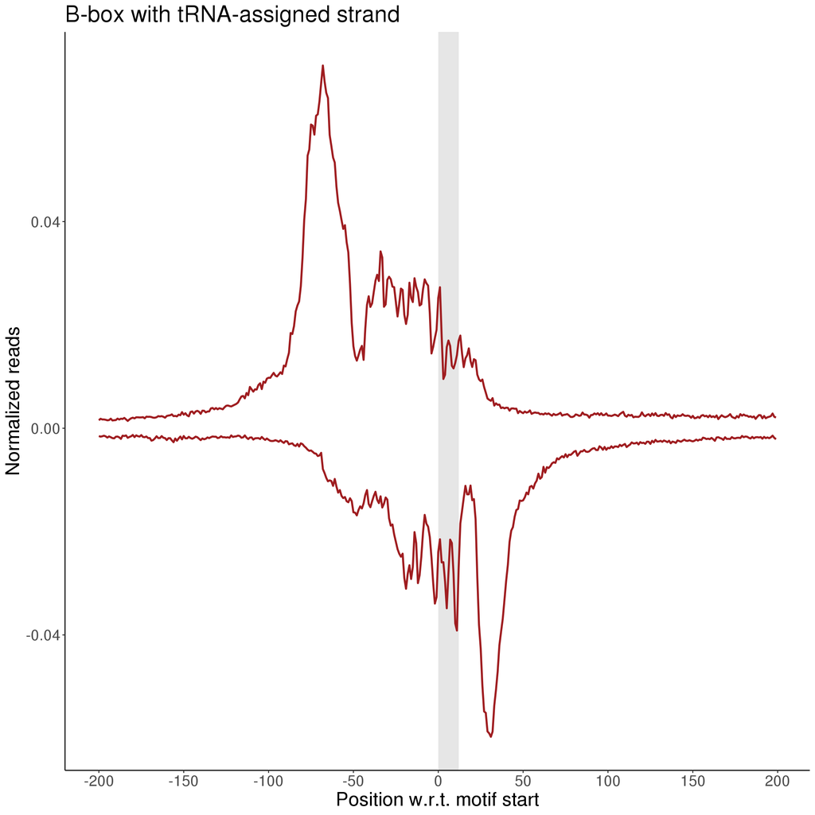

```r
#Motif combined and simplified
oct4_profile_plot_combined_summarized<-exo_metapeak(gr = resize(subset(bbox_overlap_str_reass), 1, "start"),
               sample=sample.list$oct4,
               upstream=200, downstream=200)
nexus_profiles_summarized<-ggplot(oct4_profile_plot_combined_summarized, aes(tss_distance, reads, group=strand))+
    geom_rect(aes(ymin=-Inf, ymax=Inf, xmin=0, xmax = width(bbox_overlap_str_reass)[1]), alpha=.1, fill="gray90", color="transparent")+
    geom_line(size=1, color="#9F1D20")+
    #geom_hline(yintercept=0)+
    scale_alpha_manual(values = c(1, .5), name="Strand Assignment")+
    scale_y_continuous(name="Normalized reads")+
    scale_x_continuous(name="Position w.r.t. motif start", breaks = seq(-200, 200, 50))+
    ggtitle("B-box with tRNA-assigned strand")+
    theme_classic()+
    theme(text=element_text(size=20), strip.background = element_blank(), strip.text = element_text(color="black", face="bold"))
print(nexus_profiles_summarized)
```

## Map tRNA coordinates relative to the Bbox motifs

If we flip Oct4 to the orientation of the tRNAs that the B-box occurs across, can we understand the distance between the motif and the tRNA start site?

```r
#Where is the tRNA gene start site WRT to this? (trna start - b box)
bbox_overlapping_with_trnas<-bbox_regions_trimmed_comb_with_cons[unique(trna_and_bbox_overlap@to)]
bbox_overlapping_with_trnas$distance_trna_start_to_bbox<-start(resize(trnas[(trna_and_bbox_overlap@from)], 1, "start")) - start(resize(bbox_overlap_str_reass, 1, "start"))
bbox_overlapping_with_trnas$distance_trna_end_to_bbox<-end(resize(trnas[(trna_and_bbox_overlap@from)], 1, "end")) - start(resize(bbox_overlap_str_reass, 1, "start"))

bbox_overlapping_with_trnas_distance_df<-bbox_overlapping_with_trnas %>% as.data.frame()
bbox_overlapping_with_trnas_distance_df$strand_of_trna<-strand(trnas[(trna_and_bbox_overlap@from)]) %>% as.character() #The distance is entirely strand specific
bbox_overlapping_with_trnas_distance_df$dist_corrected<-bbox_overlapping_with_trnas$distance_trna_start_to_bbox
bbox_overlapping_with_trnas_distance_df$dist_corrected[which(strand(bbox_overlap_str_reass)=="-")]<-bbox_overlapping_with_trnas_distance_df$dist_corrected[which(strand(bbox_overlap_str_reass)=="-")] * -1 #If it is on the negative strand, then correct the strand for plotting

bbox_overlapping_with_trnas_distance_df$end_dist_corrected<-bbox_overlapping_with_trnas$distance_trna_end_to_bbox
bbox_overlapping_with_trnas_distance_df$end_dist_corrected[which(strand(bbox_overlap_str_reass)=="-")]<-bbox_overlapping_with_trnas_distance_df$end_dist_corrected[which(strand(bbox_overlap_str_reass)=="-")] * -1
```

## Plot Bbox sequences with strand reorientation

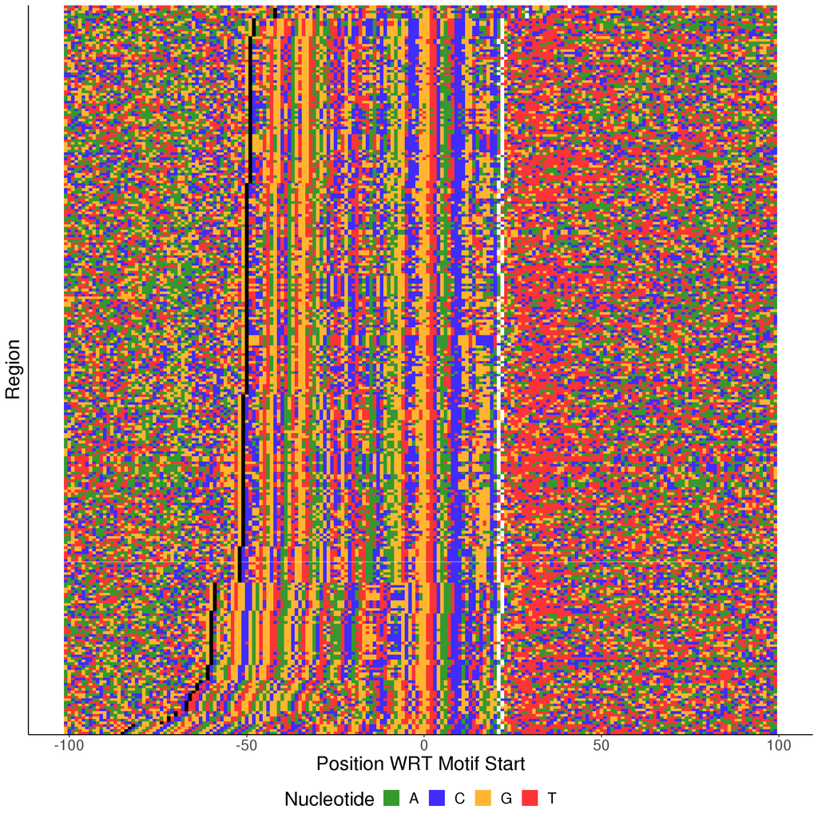

```r
#Obtain start site markers
trna_markers<-data.frame(row=1:length(bbox_overlapping_with_trnas), start_dist_from_motif=bbox_overlapping_with_trnas_distance_df$dist_corrected, end_dist_from_motif = bbox_overlapping_with_trnas_distance_df$end_dist_corrected)
trna_markers$row<-factor(trna_markers$row, levels=trna_markers$row[order(trna_markers$start_dist_from_motif)])

#Reobtain sequences
seq_df<-plot_sequence(gr = resize(bbox_overlap_str_reass, 1, "start"), genome = BSgenome.Mmusculus.UCSC.mm10,
                      title = "B-box motifs with strand reassigned to tRNAs", window = 201, cluster = F, subset=F, show=F)$df #Do not cluster for easy factor assignment
seq_df$row<-factor(seq_df$row, levels=levels(trna_markers$row))

#Plot sequences with tRNA ends overlaid
seq_with_ss_overlay<-ggplot(seq_df)+
    geom_tile(aes(x=position, y=row, fill=nt))+
    #geom_point(data=trna_start_markers, aes(x=dist_from_motif, y=row), color="black", size=1, shape=15)+
    geom_tile(data=trna_markers, aes(x=start_dist_from_motif, y=row), color="black", fill="black")+
    geom_tile(data=trna_markers, aes(x=end_dist_from_motif, y=row), color="white", fill="white")+
    xlab("Position WRT Motif Start")+
    ylab("Region")+
    scale_fill_manual(values = c("#36982F", "#402CFD", "#FFB530", "#FC3437"), name="Nucleotide")+
    theme_classic()+
    theme(text=element_text(size=20), legend.position="bottom", axis.text.y = element_blank(), axis.ticks.y = element_blank())
print(seq_with_ss_overlay)
```